# index

## **Visualization 2: Who Donates to Individual Candidates More?**

**Visualization 2.1: Democrats Who Donated Money**

**Cleaning the data**

```r
#Democrats who donated money
democrat_donations<-filter(ANES_2020,V201018==1)
democrat_donations<-filter(democrat_donations,V202017>0)
count(democrat_donations,democrat_donations$V202017==1)
```

```
# A tibble: 2 x 2
  `democrat_donations$V202017 == 1`     n
  <lgl>                             <int>
1 FALSE                              1157
2 TRUE                                531
```

```r
dem_donations<-as.data.frame(table(democrat_donations$V202017))
colnames(dem_donations)[1]<-"Donated"
colnames(dem_donations)[2]<-"Count"
```

**Graph**

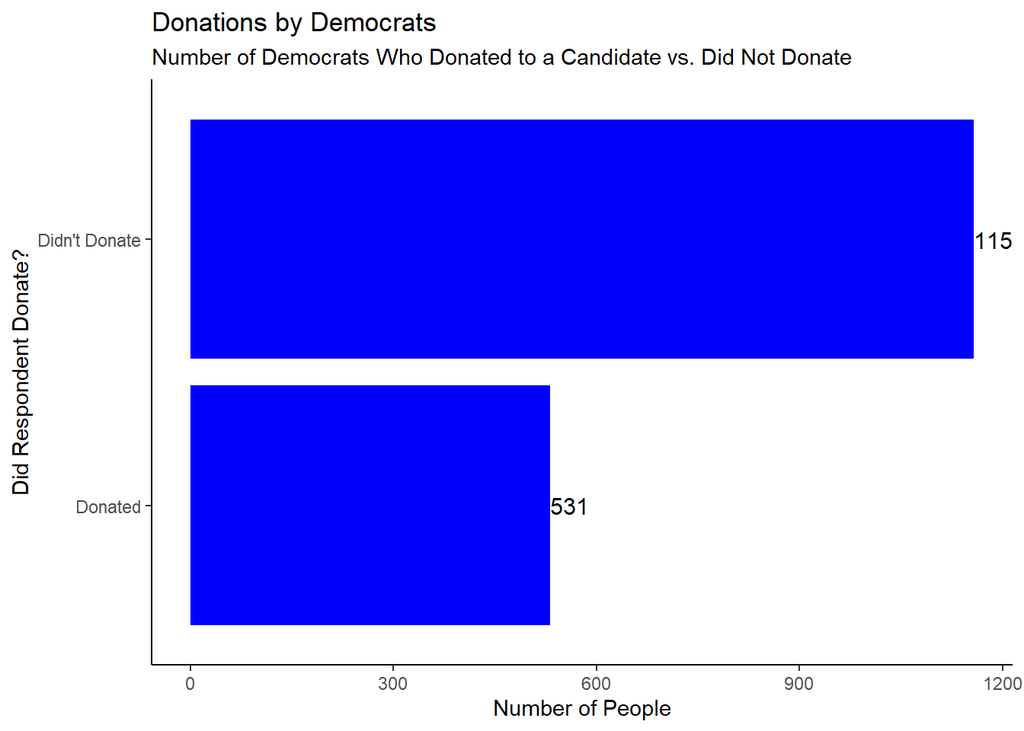

```r
dem_donations_graph<-
ggplot(data=dem_donations,
       aes(x=Donated,y=Count))+
  geom_bar(stat="identity", fill="blue")+
  scale_x_discrete(labels=c("1"="Donated","2"="Didn't Donate"))+
  geom_text(aes(label=Count), hjust=0, size=4)+
  xlab("Did Respondent Donate?")+
  ylab("Number of People")+
  ggtitle("Donations by Democrats",
          "Number of Democrats Who Donated to a Candidate vs. Did Not Donate")+
  theme_classic()+
  coord_flip()
dem_donations_graph
```

**Visualization 2.2: Republicans Who Donated Money**

**Cleaning the data**

```r
republican_donations<-filter(ANES_2020,V201018==2)
republican_donations<-filter(republican_donations,V202017>0)
count(republican_donations,republican_donations$V202017==1)
```

```
# A tibble: 2 x 2
  `republican_donations$V202017 == 1`     n
  <lgl>                               <int>
1 FALSE                                 961
2 TRUE                                  232
```

```r
republican_donations<-as.data.frame(table(republican_donations$V202017))
colnames(republican_donations)[1]<-"Donated"
colnames(republican_donations)[2]<-"Count"
```

**Graph**

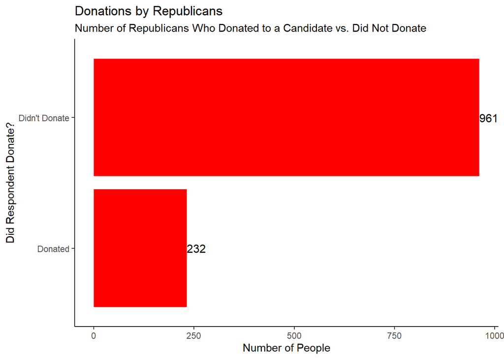

```r
republican_donations_graph<-
ggplot(data=republican_donations,
       aes(x=Donated,y=Count))+
  geom_bar(stat="identity", fill="red")+
  scale_x_discrete(labels=c("1"="Donated","2"="Didn't Donate"))+
  geom_text(aes(label=Count), hjust=0, size=4)+
  xlab("Did Respondent Donate?")+
  ylab("Number of People")+
  ggtitle("Donations by Republicans",
          "Number of Republicans Who Donated to a Candidate vs. Did Not Donate")+
  theme_classic()+
  coord_flip()
republican_donations_graph
```

**Complete Visualization 2**

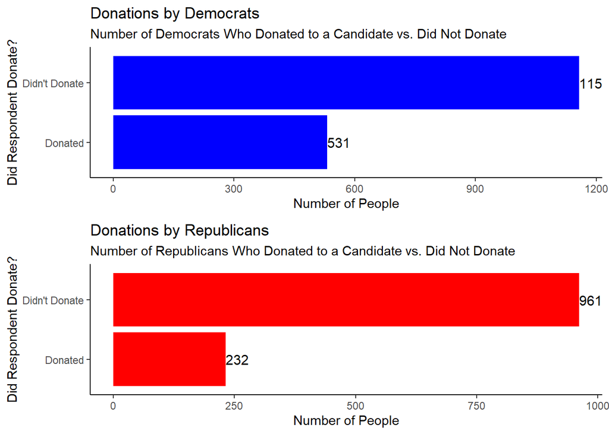

```r
grid.arrange(dem_donations_graph,republican_donations_graph,ncol=1, nrow=2)
```

**Summary of visualization 2**

The second visualization shows the number of respondents who did and did not donate to an individual candidate in the 2020 election broken down by party. Looking at the two graphs next to one another, you can see that Democrats donated at a higher frequency than Republicans did. This does not speak to the amount donated by the respondents, but indicates that there were more individual donors among Democrat respondents than Republican respondents.